# Factor Analysis

This technique is designed to uncover latent factors underlying observed data. It assumes that the features are simply manifestations of deeper constructs. This is often the case in data used in the social sciences and business.

In the Scikit-Learn framework, the module sklearn.decomposition contains a function called FactorAnalysis() for performing factor analysis. However, it implements a probabilistic factor analysis rather than the classical psychometric factor analysis used in the social sciences. Moreover, Scikit-Learn lacks useful functions for evaluation and interpreting factor analysis results. Therefore, we will use an alternative library, factor_analyzer.

```python
import numpy as np
import pandas as pd
import matplotlib.pyplot as plt
import seaborn as sns
from factor_analyzer import FactorAnalyzer
from factor_analyzer.factor_analyzer import calculate_bartlett_sphericity, calculate_kmo
import warnings
warnings.filterwarnings('ignore')
```

## Data

The [data](https://openpsychometrics.org/_rawdata/) describes survey items from scales of Grit and the Big 5 Personality traits. This is derived from a study by Duckworth et al (2007) where they used a set of likert-type statements to measure Grit and five personality traits. The features we will examine are grouped under the constructs they are meant to reflect. You can find the full scale [here](https://ipip.ori.org/new_ipip-50-item-scale.htm).  
- Grit: GS1 to GS12  
- Extraversion: E1 to E10  
- Neuroticism: N1 to N10  
- Agreeableness: A1 to A10  
- Conscientiousness: C1 to C10  
- Openness to Experience: O1 to O10

Here is the full scale:

- E1 I am the life of the party.
- E2 I don’t talk a lot.
- E3 I feel comfortable around people.
- E4 I keep in the background.
- E5 I start conversations.
- E6 I have little to say.
- E7 I talk to a lot of different people at parties.
- E8 I don’t like to draw attention to myself.
- E9 I don’t mind being the center of attention.
- E10 I am quiet around strangers.
- N1 I get stressed out easily.
- N2 I am relaxed most of the time.
- N3 I worry about things.
- N4 I seldom feel blue.
- N5 I am easily disturbed.
- N6 I get upset easily.
- N7 I change my mood a lot.
- N8 I have frequent mood swings.
- N9 I get irritated easily.
- N10 I often feel blue.
- A1 I feel little concern for others.
- A2 I am interested in people.
- A3 I insult people.
- A4 I sympathize with others’ feelings.
- A5 I am not interested in other people’s problems.
- A6 I have a soft heart.
- A7 I am not really interested in others.
- A8 I take time out for others.
- A9 I feel others’ emotions.
- A10 I make people feel at ease.
- C1 I am always prepared.
- C2 I leave my belongings around.
- C3 I pay attention to details.
- C4 I make a mess of things.
- C5 I get chores done right away.
- C6 I often forget to put things back in their proper place.
- C7 I like order.
- C8 I shirk my duties.
- C9 I follow a schedule.
- C10 I am exacting in my work.
- O1 I have a rich vocabulary.
- O2 I have difficulty understanding abstract ideas.
- O3 I have a vivid imagination.
- O4 I am not interested in abstract ideas.
- O5 I have excellent ideas.
- O6 I do not have a good imagination.
- O7 I am quick to understand things.
- O8 I use difficult words.
- O9 I spend time reflecting on things.
- O10 I am full of ideas.

```python
data = pd.read_csv("data.csv",delimiter='\t')
data.columns
```

```
Index(['country', 'surveyelapse', 'GS1', 'GS2', 'GS3', 'GS4', 'GS5', 'GS6',
       'GS7', 'GS8', 'GS9', 'GS10', 'GS11', 'GS12', 'VCL1', 'VCL2', 'VCL3',
       'VCL4', 'VCL5', 'VCL6', 'VCL7', 'VCL8', 'VCL9', 'VCL10', 'VCL11',
       'VCL12', 'VCL13', 'VCL14', 'VCL15', 'VCL16', 'education', 'urban',
       'gender', 'engnat', 'age', 'hand', 'religion', 'orientation', 'race',
       'voted', 'married', 'familysize', 'E1', 'E2', 'E3', 'E4', 'E5', 'E6',
       'E7', 'E8', 'E9', 'E10', 'N1', 'N2', 'N3', 'N4', 'N5', 'N6', 'N7', 'N8',
       'N9', 'N10', 'A1', 'A2', 'A3', 'A4', 'A5', 'A6', 'A7', 'A8', 'A9',
       'A10', 'C1', 'C2', 'C3', 'C4', 'C5', 'C6', 'C7', 'C8', 'C9', 'C10',
       'O1', 'O2', 'O3', 'O4', 'O5', 'O6', 'O7', 'O8', 'O9', 'O10',
       'operatingsystem', 'browser', 'screenw', 'screenh', 'introelapse',
       'testelapse'],
      dtype='object')
```

- For this illustration, we will focus on the items corresponding to the Big Five Personality Traits. Accordingly, we will extract items, E1 to O10.
- A few items in the survey above are oppositely worded. These need to be reverse scored (e.g., replace 1 with 7, 2 with 6, etc.). The following items need to be reverse scored: E2, E4, E6, E8, E10, N2, N4, A1, A3, A5, A7, C2, C4, C6, C8, O2, O4, O6.
- Since the range of the scale is 0 to 5, a simple way to reverse score is to subtract from the range, 5.

```python
survey = data.loc[:,'E1':'O10']
survey.loc[:,['E2', 'E4', 'E6', 'E8', 'E10', 'N2', 'N4', 'A1', 'A3', 'A5', 'A7', 'C2', 'C4', 'C6', 'C8', 'O2', 'O4', 'O6']] = 5 - survey.loc[:,['E2', 'E4', 'E6', 'E8', 'E10', 'N2', 'N4', 'A1', 'A3', 'A5', 'A7', 'C2', 'C4', 'C6', 'C8', 'O2', 'O4', 'O6']]
```

## Explore Data

Examine data for outliers and missing values.

```python
survey.describe()
```

|  | E1 | E2 | E3 | E4 | E5 | E6 | E7 | E8 | E9 | E10 | ... | O1 | O2 | O3 | O4 | O5 | O6 | O7 | O8 | O9 | O10 |
| --- | --- | --- | --- | --- | --- | --- | --- | --- | --- | --- | --- | --- | --- | --- | --- | --- | --- | --- | --- | --- | --- |
| count | 4270.000000 | 4270.000000 | 4270.00000 | 4270.000000 | 4270.000000 | 4270.000000 | 4270.000000 | 4270.000000 | 4270.00000 | 4270.000000 | ... | 4270.000000 | 4270.000000 | 4270.000000 | 4270.000000 | 4270.000000 | 4270.000000 | 4270.000000 | 4270.000000 | 4270.000000 | 4270.000000 |
| mean | 2.733255 | 2.307494 | 3.37096 | 1.924590 | 3.375176 | 2.620609 | 2.840281 | 1.622717 | 3.01007 | 1.446604 | ... | 3.677049 | 2.845433 | 4.059485 | 2.904684 | 3.864637 | 3.127635 | 4.010773 | 3.168618 | 4.108431 | 3.988993 |
| std | 1.275127 | 1.333503 | 1.20536 | 1.239027 | 1.238956 | 1.226454 | 1.416123 | 1.264614 | 1.34777 | 1.307431 | ... | 1.109770 | 1.117168 | 1.064877 | 1.127418 | 0.942945 | 1.105729 | 0.961365 | 1.255449 | 1.014858 | 1.021723 |
| min | 0.000000 | 0.000000 | 0.00000 | 0.000000 | 0.000000 | 0.000000 | 0.000000 | 0.000000 | 0.00000 | 0.000000 | ... | 0.000000 | 0.000000 | 0.000000 | 0.000000 | 0.000000 | 0.000000 | 0.000000 | 0.000000 | 0.000000 | 0.000000 |
| 25% | 2.000000 | 1.000000 | 3.00000 | 1.000000 | 3.000000 | 2.000000 | 2.000000 | 1.000000 | 2.00000 | 0.000000 | ... | 3.000000 | 2.000000 | 3.000000 | 2.000000 | 3.000000 | 3.000000 | 3.000000 | 2.000000 | 4.000000 | 3.000000 |
| 50% | 3.000000 | 2.000000 | 3.00000 | 2.000000 | 4.000000 | 3.000000 | 3.000000 | 2.000000 | 3.00000 | 1.000000 | ... | 4.000000 | 3.000000 | 4.000000 | 3.000000 | 4.000000 | 3.000000 | 4.000000 | 3.000000 | 4.000000 | 4.000000 |
| 75% | 4.000000 | 3.000000 | 4.00000 | 3.000000 | 4.000000 | 4.000000 | 4.000000 | 3.000000 | 4.00000 | 2.000000 | ... | 5.000000 | 4.000000 | 5.000000 | 4.000000 | 5.000000 | 4.000000 | 5.000000 | 4.000000 | 5.000000 | 5.000000 |
| max | 5.000000 | 5.000000 | 5.00000 | 5.000000 | 5.000000 | 5.000000 | 5.000000 | 5.000000 | 5.00000 | 5.000000 | ... | 5.000000 | 5.000000 | 5.000000 | 5.000000 | 5.000000 | 5.000000 | 5.000000 | 5.000000 | 5.000000 | 5.000000 |

8 rows × 50 columns

```python
survey.isna().sum(axis = 0)
```

```
E1     0
E2     0
E3     0
E4     0
E5     0
E6     0
E7     0
E8     0
E9     0
E10    0
N1     0
N2     0
N3     0
N4     0
N5     0
N6     0
N7     0
N8     0
N9     0
N10    0
A1     0
A2     0
A3     0
A4     0
A5     0
A6     0
A7     0
A8     0
A9     0
A10    0
C1     0
C2     0
C3     0
C4     0
C5     0
C6     0
C7     0
C8     0
C9     0
C10    0
O1     0
O2     0
O3     0
O4     0
O5     0
O6     0
O7     0
O8     0
O9     0
O10    0
dtype: int64
```

## Suitability

The items included in survey are meant to represent the Big Five personality traits. This meets the first requirement.

The second requirement of feature correlations can be examined by three tests  
- Correlation matrix: Pattern of bivariate correlations should involve some large and some small correlations.  
- Bartlett’s Test of Sphericity: This test which compares the correlation matrix to an identity matrix should indicate a statistically singificant difference.  
- KMO’s Measure of Sampling Adequacy (MSA): The index must be above 0.5. Closer to 1 is better.

### Correlation Matrix

```python
survey.corr().round(2)
```

|  | E1 | E2 | E3 | E4 | E5 | E6 | E7 | E8 | E9 | E10 | ... | O1 | O2 | O3 | O4 | O5 | O6 | O7 | O8 | O9 | O10 |
| --- | --- | --- | --- | --- | --- | --- | --- | --- | --- | --- | --- | --- | --- | --- | --- | --- | --- | --- | --- | --- | --- |
| E1 | 1.00 | 0.44 | 0.46 | 0.51 | 0.49 | 0.34 | 0.57 | 0.37 | 0.48 | 0.42 | ... | 0.05 | 0.03 | 0.08 | 0.03 | 0.20 | 0.08 | 0.10 | 0.05 | -0.07 | 0.19 |
| E2 | 0.44 | 1.00 | 0.43 | 0.54 | 0.53 | 0.54 | 0.46 | 0.36 | 0.38 | 0.50 | ... | 0.06 | 0.06 | 0.05 | 0.04 | 0.12 | 0.08 | 0.07 | 0.03 | -0.08 | 0.15 |
| E3 | 0.46 | 0.43 | 1.00 | 0.47 | 0.57 | 0.36 | 0.54 | 0.32 | 0.41 | 0.48 | ... | 0.03 | 0.07 | 0.01 | 0.03 | 0.17 | 0.06 | 0.14 | -0.04 | -0.07 | 0.15 |
| E4 | 0.51 | 0.54 | 0.47 | 1.00 | 0.49 | 0.46 | 0.50 | 0.45 | 0.46 | 0.53 | ... | 0.05 | 0.07 | -0.01 | 0.05 | 0.14 | 0.06 | 0.08 | 0.00 | -0.08 | 0.13 |
| E5 | 0.49 | 0.53 | 0.57 | 0.49 | 1.00 | 0.45 | 0.58 | 0.34 | 0.42 | 0.54 | ... | 0.11 | 0.08 | 0.08 | 0.07 | 0.21 | 0.09 | 0.15 | 0.04 | -0.02 | 0.22 |
| E6 | 0.34 | 0.54 | 0.36 | 0.46 | 0.45 | 1.00 | 0.37 | 0.30 | 0.33 | 0.42 | ... | 0.17 | 0.21 | 0.11 | 0.17 | 0.24 | 0.18 | 0.15 | 0.12 | 0.03 | 0.26 |
| E7 | 0.57 | 0.46 | 0.54 | 0.50 | 0.58 | 0.37 | 1.00 | 0.33 | 0.44 | 0.51 | ... | 0.07 | 0.04 | 0.06 | 0.03 | 0.18 | 0.05 | 0.11 | 0.04 | -0.05 | 0.18 |
| E8 | 0.37 | 0.36 | 0.32 | 0.45 | 0.34 | 0.30 | 0.33 | 1.00 | 0.52 | 0.39 | ... | 0.04 | 0.07 | 0.07 | 0.05 | 0.14 | 0.09 | 0.03 | 0.02 | -0.07 | 0.12 |
| E9 | 0.48 | 0.38 | 0.41 | 0.46 | 0.42 | 0.33 | 0.44 | 0.52 | 1.00 | 0.41 | ... | 0.11 | 0.09 | 0.11 | 0.06 | 0.24 | 0.11 | 0.17 | 0.13 | -0.02 | 0.23 |
| E10 | 0.42 | 0.50 | 0.48 | 0.53 | 0.54 | 0.42 | 0.51 | 0.39 | 0.41 | 1.00 | ... | 0.08 | 0.12 | 0.02 | 0.06 | 0.15 | 0.08 | 0.12 | 0.04 | -0.10 | 0.13 |
| N1 | -0.13 | -0.04 | -0.21 | -0.14 | -0.13 | -0.08 | -0.11 | -0.09 | -0.13 | -0.19 | ... | -0.04 | -0.16 | 0.02 | -0.05 | -0.14 | -0.06 | -0.17 | 0.03 | 0.11 | -0.11 |
| N2 | -0.14 | -0.03 | -0.27 | -0.06 | -0.14 | -0.01 | -0.13 | -0.03 | -0.13 | -0.07 | ... | -0.03 | -0.06 | -0.03 | 0.00 | -0.12 | -0.03 | -0.14 | 0.04 | 0.06 | -0.09 |
| N3 | -0.12 | -0.08 | -0.19 | -0.17 | -0.13 | -0.07 | -0.13 | -0.10 | -0.12 | -0.21 | ... | -0.05 | -0.13 | 0.05 | -0.02 | -0.09 | -0.04 | -0.09 | 0.01 | 0.17 | -0.07 |
| N4 | -0.11 | -0.05 | -0.20 | -0.12 | -0.12 | -0.03 | -0.10 | -0.07 | -0.13 | -0.09 | ... | 0.02 | 0.00 | 0.01 | 0.04 | -0.09 | 0.00 | -0.09 | 0.04 | 0.09 | -0.04 |
| N5 | -0.06 | -0.05 | -0.17 | -0.12 | -0.10 | -0.14 | -0.08 | -0.04 | -0.07 | -0.13 | ... | -0.10 | -0.20 | 0.00 | -0.13 | -0.11 | -0.10 | -0.16 | -0.03 | 0.03 | -0.11 |
| N6 | -0.10 | -0.04 | -0.22 | -0.14 | -0.13 | -0.11 | -0.13 | -0.07 | -0.08 | -0.18 | ... | -0.08 | -0.18 | 0.04 | -0.10 | -0.12 | -0.08 | -0.14 | 0.02 | 0.07 | -0.11 |
| N7 | -0.02 | -0.03 | -0.22 | -0.14 | -0.11 | -0.08 | -0.08 | -0.01 | -0.02 | -0.16 | ... | -0.05 | -0.11 | 0.10 | -0.05 | -0.09 | -0.02 | -0.09 | 0.07 | 0.08 | -0.03 |
| N8 | -0.06 | -0.03 | -0.23 | -0.15 | -0.13 | -0.09 | -0.11 | -0.01 | -0.03 | -0.14 | ... | -0.07 | -0.12 | 0.08 | -0.06 | -0.11 | -0.04 | -0.10 | 0.06 | 0.09 | -0.06 |
| N9 | -0.09 | -0.05 | -0.26 | -0.15 | -0.15 | -0.12 | -0.15 | -0.08 | -0.07 | -0.20 | ... | -0.06 | -0.17 | 0.01 | -0.13 | -0.10 | -0.10 | -0.13 | 0.05 | 0.06 | -0.11 |
| N10 | -0.20 | -0.18 | -0.37 | -0.28 | -0.25 | -0.19 | -0.23 | -0.12 | -0.16 | -0.25 | ... | 0.01 | -0.06 | 0.06 | -0.02 | -0.13 | -0.06 | -0.11 | 0.09 | 0.14 | -0.05 |
| A1 | 0.03 | 0.12 | 0.13 | 0.11 | 0.10 | 0.16 | 0.08 | -0.02 | -0.02 | 0.08 | ... | 0.11 | 0.12 | 0.03 | 0.12 | -0.00 | 0.06 | 0.04 | 0.04 | 0.11 | 0.03 |
| A2 | 0.25 | 0.26 | 0.43 | 0.23 | 0.35 | 0.26 | 0.31 | 0.15 | 0.21 | 0.24 | ... | 0.09 | 0.07 | 0.08 | 0.13 | 0.10 | 0.07 | 0.10 | 0.02 | 0.11 | 0.14 |
| A3 | -0.07 | -0.04 | 0.11 | 0.02 | 0.01 | -0.01 | -0.00 | -0.04 | -0.09 | 0.04 | ... | -0.04 | 0.06 | -0.05 | 0.10 | -0.01 | 0.03 | 0.03 | -0.13 | 0.04 | -0.00 |
| A4 | 0.08 | 0.11 | 0.22 | 0.06 | 0.18 | 0.08 | 0.13 | 0.01 | 0.03 | 0.04 | ... | 0.00 | 0.02 | 0.09 | 0.07 | -0.00 | 0.06 | 0.04 | -0.06 | 0.16 | 0.04 |
| A5 | 0.08 | 0.19 | 0.22 | 0.15 | 0.21 | 0.20 | 0.13 | 0.08 | 0.05 | 0.14 | ... | 0.01 | 0.06 | 0.01 | 0.14 | 0.00 | 0.09 | 0.02 | -0.04 | 0.09 | 0.04 |
| A6 | 0.05 | 0.06 | 0.13 | 0.01 | 0.11 | -0.01 | 0.05 | -0.01 | -0.00 | -0.03 | ... | -0.07 | -0.06 | 0.06 | 0.02 | 0.01 | 0.03 | -0.02 | -0.10 | 0.12 | 0.02 |
| A7 | 0.21 | 0.29 | 0.36 | 0.27 | 0.33 | 0.30 | 0.28 | 0.15 | 0.16 | 0.23 | ... | 0.04 | 0.09 | 0.04 | 0.17 | 0.04 | 0.12 | 0.06 | -0.05 | 0.10 | 0.10 |
| A8 | 0.14 | 0.16 | 0.26 | 0.11 | 0.24 | 0.14 | 0.19 | -0.01 | 0.07 | 0.08 | ... | 0.01 | 0.04 | 0.04 | 0.06 | 0.06 | 0.04 | 0.07 | -0.00 | 0.13 | 0.09 |
| A9 | 0.11 | 0.13 | 0.21 | 0.10 | 0.19 | 0.10 | 0.15 | 0.05 | 0.09 | 0.06 | ... | 0.01 | 0.05 | 0.12 | 0.09 | 0.05 | 0.10 | 0.05 | -0.02 | 0.17 | 0.09 |
| A10 | 0.30 | 0.24 | 0.39 | 0.23 | 0.36 | 0.23 | 0.32 | 0.12 | 0.22 | 0.24 | ... | 0.06 | 0.08 | 0.09 | 0.08 | 0.17 | 0.10 | 0.17 | -0.00 | 0.07 | 0.17 |
| C1 | 0.03 | -0.01 | 0.14 | 0.03 | 0.10 | 0.05 | 0.07 | -0.01 | 0.02 | 0.02 | ... | 0.09 | 0.07 | -0.04 | 0.02 | 0.18 | -0.00 | 0.20 | 0.02 | 0.04 | 0.07 |
| C2 | -0.02 | -0.06 | 0.02 | 0.04 | -0.02 | -0.00 | -0.01 | -0.01 | -0.07 | 0.01 | ... | -0.08 | -0.01 | -0.12 | -0.06 | 0.01 | -0.02 | 0.02 | -0.11 | -0.03 | -0.08 |
| C3 | 0.03 | -0.03 | 0.07 | -0.04 | 0.08 | 0.06 | 0.04 | -0.03 | 0.04 | -0.01 | ... | 0.14 | 0.15 | 0.11 | 0.11 | 0.20 | 0.11 | 0.24 | 0.09 | 0.16 | 0.17 |
| C4 | 0.03 | 0.03 | 0.18 | 0.13 | 0.11 | 0.11 | 0.06 | 0.02 | 0.00 | 0.11 | ... | 0.04 | 0.10 | -0.12 | 0.05 | 0.14 | 0.01 | 0.13 | -0.08 | -0.05 | 0.01 |
| C5 | 0.06 | -0.01 | 0.15 | 0.07 | 0.13 | -0.01 | 0.10 | 0.03 | 0.01 | 0.07 | ... | -0.02 | -0.01 | -0.06 | -0.04 | 0.09 | -0.01 | 0.09 | -0.07 | 0.01 | 0.02 |
| C6 | 0.01 | -0.01 | 0.07 | 0.05 | 0.04 | 0.05 | 0.04 | 0.01 | -0.03 | 0.06 | ... | -0.02 | 0.03 | -0.11 | -0.03 | 0.01 | 0.00 | 0.06 | -0.08 | -0.01 | -0.05 |
| C7 | -0.03 | -0.03 | 0.03 | -0.04 | 0.04 | 0.03 | -0.01 | -0.06 | -0.02 | -0.06 | ... | 0.06 | -0.05 | -0.06 | -0.06 | 0.07 | -0.05 | 0.11 | 0.03 | 0.11 | -0.00 |
| C8 | 0.01 | 0.04 | 0.14 | 0.10 | 0.11 | 0.12 | 0.05 | 0.02 | 0.00 | 0.10 | ... | 0.07 | 0.10 | -0.06 | 0.07 | 0.10 | 0.04 | 0.14 | -0.01 | 0.01 | 0.04 |
| C9 | 0.04 | 0.02 | 0.12 | 0.05 | 0.11 | 0.02 | 0.07 | -0.02 | 0.00 | 0.01 | ... | 0.01 | -0.03 | -0.08 | -0.04 | 0.07 | -0.03 | 0.08 | -0.03 | 0.06 | 0.03 |
| C10 | 0.05 | 0.01 | 0.09 | 0.04 | 0.09 | 0.06 | 0.05 | -0.00 | 0.06 | 0.02 | ... | 0.15 | 0.09 | 0.06 | 0.06 | 0.23 | 0.07 | 0.25 | 0.13 | 0.12 | 0.20 |
| O1 | 0.05 | 0.06 | 0.03 | 0.05 | 0.11 | 0.17 | 0.07 | 0.04 | 0.11 | 0.08 | ... | 1.00 | 0.31 | 0.21 | 0.23 | 0.31 | 0.18 | 0.31 | 0.63 | 0.18 | 0.30 |
| O2 | 0.03 | 0.06 | 0.07 | 0.07 | 0.08 | 0.21 | 0.04 | 0.07 | 0.09 | 0.12 | ... | 0.31 | 1.00 | 0.23 | 0.51 | 0.27 | 0.30 | 0.32 | 0.25 | 0.18 | 0.33 |
| O3 | 0.08 | 0.05 | 0.01 | -0.01 | 0.08 | 0.11 | 0.06 | 0.07 | 0.11 | 0.02 | ... | 0.21 | 0.23 | 1.00 | 0.28 | 0.28 | 0.51 | 0.12 | 0.20 | 0.24 | 0.43 |
| O4 | 0.03 | 0.04 | 0.03 | 0.05 | 0.07 | 0.17 | 0.03 | 0.05 | 0.06 | 0.06 | ... | 0.23 | 0.51 | 0.28 | 1.00 | 0.22 | 0.30 | 0.17 | 0.22 | 0.22 | 0.31 |
| O5 | 0.20 | 0.12 | 0.17 | 0.14 | 0.21 | 0.24 | 0.18 | 0.14 | 0.24 | 0.15 | ... | 0.31 | 0.27 | 0.28 | 0.22 | 1.00 | 0.29 | 0.37 | 0.26 | 0.17 | 0.59 |
| O6 | 0.08 | 0.08 | 0.06 | 0.06 | 0.09 | 0.18 | 0.05 | 0.09 | 0.11 | 0.08 | ... | 0.18 | 0.30 | 0.51 | 0.30 | 0.29 | 1.00 | 0.12 | 0.14 | 0.15 | 0.41 |
| O7 | 0.10 | 0.07 | 0.14 | 0.08 | 0.15 | 0.15 | 0.11 | 0.03 | 0.17 | 0.12 | ... | 0.31 | 0.32 | 0.12 | 0.17 | 0.37 | 0.12 | 1.00 | 0.28 | 0.12 | 0.30 |
| O8 | 0.05 | 0.03 | -0.04 | 0.00 | 0.04 | 0.12 | 0.04 | 0.02 | 0.13 | 0.04 | ... | 0.63 | 0.25 | 0.20 | 0.22 | 0.26 | 0.14 | 0.28 | 1.00 | 0.18 | 0.27 |
| O9 | -0.07 | -0.08 | -0.07 | -0.08 | -0.02 | 0.03 | -0.05 | -0.07 | -0.02 | -0.10 | ... | 0.18 | 0.18 | 0.24 | 0.22 | 0.17 | 0.15 | 0.12 | 0.18 | 1.00 | 0.21 |
| O10 | 0.19 | 0.15 | 0.15 | 0.13 | 0.22 | 0.26 | 0.18 | 0.12 | 0.23 | 0.13 | ... | 0.30 | 0.33 | 0.43 | 0.31 | 0.59 | 0.41 | 0.30 | 0.27 | 0.21 | 1.00 |

50 rows × 50 columns

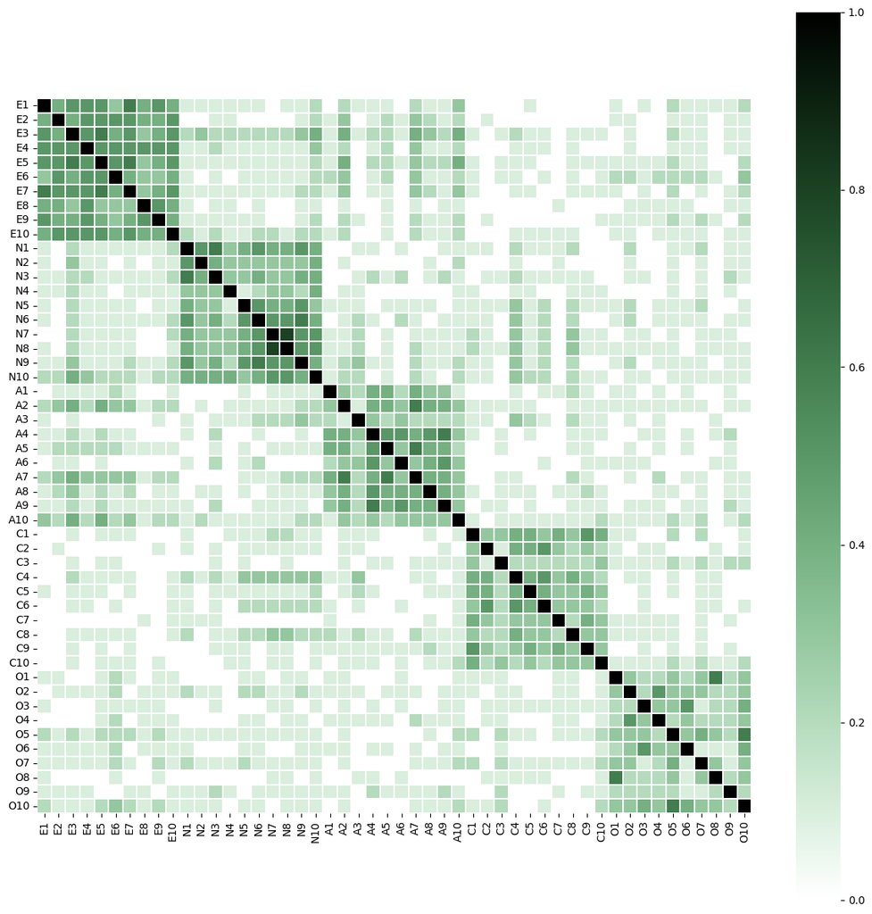

```python
plt.figure(figsize=(15,15))
pal = sns.cubehelix_palette(start=2, rot=0, dark=1, light=0, reverse=True, as_cmap=True)
sns.heatmap(round(survey.corr().abs(),1), annot=False, cmap=pal,
            linewidths=0.2, square=True)
plt.plot()
```

```python
total_elements = len(survey.corr())**2# number of elements in correlation matrix
large_r = (survey.corr().abs()>0.3).sum().sum()  # number of correlations greater than 0.3
print('Percent correlations greater than 0.3: ', (large_r/total_elements)*100)
```

```
Percent correlations greater than 0.3:  14.719999999999999
```

### Bartlett’s Test of Sphericity

Bartlett’s Test of Sphericity assesses if the correlation matrix is significantly different from an identity matrix, indicating that variables are sufficiently correlated to justify the use of factor analysis. A significant chi-squared value indicates correlations are strong enough and the data is suitable for factor analysis.

```python
chi_square, p_value = calculate_bartlett_sphericity(survey)
print(f'Chi-Square: {chi_square}')
print(f'p-value: {p_value}')
```

```
Chi-Square: 80974.62577704886
p-value: 0.0
```

### KMO Measure of Sampling Adequacy

The Kaiser-Meyer-Olkin (KMO) measure of sampling adequacy is indicates the proportion of variance that can be explained by underlying factors. A high KMO’s MSA value suggests that the data is well-suited for factor analysis, while values below 0.50 are considered unacceptable.

```python
kmo_each, kmo_overall = calculate_kmo(survey)
print(f'Overall KMO = {kmo_overall}')
```

```
Overall KMO = 0.9054635892554692
```

### Number of Features relative to observations

Ratio of observations to features should be greater than 5:1.

```python
print('Number of Features:', len(survey.columns))
print('Number of observations:', len(survey))
```

```
Number of Features: 50
Number of observations: 4270
```

### Sample Size

Generally, sample size should be greater than 100.

```python
print('Sample Size:', len(survey))
```

```
Sample Size: 4270
```

## Data Preparation

- Missing values: Impute missing values to avoid listwise deletion, the default.
- Standardize Variables: Factor analysis is sensitive to measurement scale.
- Categorical variables: Unless, absolutely necessary categorical variables should not be included as factor analysis algorithms work best when all variables are of the same type. If necessary, dummy code categorical variables before including in analysis.
- Outliers: Extreme observations may bias factor structure.

```python
from sklearn.preprocessing import StandardScaler
scale = StandardScaler()
survey_scaled = scale.fit_transform(survey)
```

## Number of Factors

The decision of number of factors should be informed by theory. Since, the 50 items are being used to capture five personality traits, we expect to find five factors.

We will examine a few data driven methods to confirm our apriori expectation of five factors.

- Eigen Value greater than one
- Elbow in scree plot
- Parallel analysis
- Total variance greater than 70%
- Communalities

```python
temp_fa = FactorAnalyzer(n_factors = 50, rotation = None)
temp_fa.fit(survey_scaled)
```

```
FactorAnalyzer(n_factors=50, rotation=None, rotation_kwargs={})
```

### Eigen Value greater than 1

Based on this criterion, only factors with eigen value greater than 1 are retained. Thus, based on this criterion 8 factors should be retained.

```python
eigen_values = temp_fa.get_eigenvalues()[0]
print('Number of factors with eigen greater than 1:', np.sum(eigen_values>1))
pd.DataFrame({'factor':np.arange(1,51),
              'eigen_value':eigen_values}).head(10)
```

```
Number of factors with eigen greater than 1: 8
```

|  | factor | eigen_value |
| --- | --- | --- |
| 0 | 1 | 7.811182 |
| 1 | 2 | 4.661837 |
| 2 | 3 | 3.893668 |
| 3 | 4 | 3.432943 |
| 4 | 5 | 2.892211 |
| 5 | 6 | 1.571835 |
| 6 | 7 | 1.376118 |
| 7 | 8 | 1.041158 |
| 8 | 9 | 0.973009 |
| 9 | 10 | 0.928429 |

### Elbow in Scree Plot

The sharp drop in eigen values following the fifth factor suggests there are 5 factors.

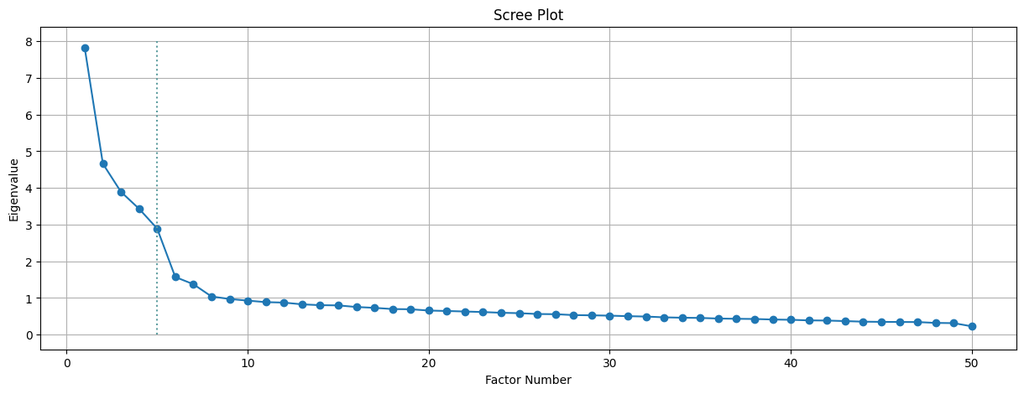

```python
plt.figure(figsize = (15,5))
plt.plot(range(1,51), eigen_values, marker = 'o')
#sns.lineplot(y = eigen, x=range(1,51), color = 'red')
plt.grid()
plt.xlabel('Factor Number')
plt.ylabel('Eigenvalue')
plt.title('Scree Plot')
plt.vlines(5,linestyles='dotted', colors='cadetblue',ymin =0, ymax = 8)
plt.show()
```

### Parallel Analysis

Simulate a dataset with same variables and observations as original dataset. Compute correlation matrix and eigen values. Now, compare eigen values from simulated data to original data. Select factors with eigen values in the original data greater than eigen values in the simulated data.

```
Number of factors from parallel analysis: 7
```

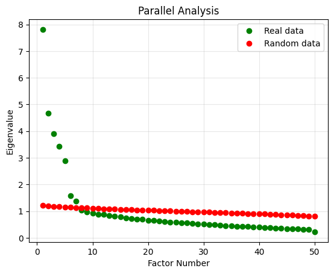

```python
n_simulations = 100
random_eigenvalues = []
for _ in range(n_simulations):
    random_data = np.random.normal(0, 1, survey_scaled.shape)
    random_corr = np.corrcoef(random_data.T)
    random_eigenvals = np.linalg.eigvals(random_corr)
    random_eigenvalues.append(np.sort(random_eigenvals)[::-1])

# Calculate mean random eigenvalues
mean_random_eigenvalues = np.mean(random_eigenvalues, axis=0)

# Find where real eigenvalues exceed random
parallel_factors = sum(eigen_values > mean_random_eigenvalues)
print("Number of factors from parallel analysis:", parallel_factors)

# Plot parallel analysis
plt.plot(range(1, len(eigen_values) + 1), eigen_values, 'go', label='Real data')
plt.plot(range(1, len(mean_random_eigenvalues) + 1), mean_random_eigenvalues, 'ro', label='Random data')
plt.xlabel('Factor Number')
plt.ylabel('Eigenvalue')
plt.title('Parallel Analysis')
plt.legend()
plt.grid(True, alpha=0.3)
plt.show()
```

### Total Variance Explained

Representing a large number of items with a fewer number of factors is expected to result in loss of information. The goal is to ensure that 70% or more information is retained. In certain situations, this threshold may be lowered to 60%. In this data, it takes 12 factors to cross the 60% threshold and 19 to exceed 70% threshold.

```python
variance_explained = pd.DataFrame({'Factor_Number': range(1,51),
              'Eigen_Value': eigen_values,
              'Variance_Explained': 100*eigen_values/np.sum(eigen_values),
              'Cumulative_Variance': np.cumsum(100*eigen_values/np.sum(eigen_values))}).round(2)
print('Number of factors to explain 60% or more variance is', (~(variance_explained.Cumulative_Variance>60)).sum() + 1)
variance_explained.head(30)
```

```
Number of factors to explain 60% or more variance is 12
```

|  | Factor_Number | Eigen_Value | Variance_Explained | Cumulative_Variance |
| --- | --- | --- | --- | --- |
| 0 | 1 | 7.81 | 15.62 | 15.62 |
| 1 | 2 | 4.66 | 9.32 | 24.95 |
| 2 | 3 | 3.89 | 7.79 | 32.73 |
| 3 | 4 | 3.43 | 6.87 | 39.60 |
| 4 | 5 | 2.89 | 5.78 | 45.38 |
| 5 | 6 | 1.57 | 3.14 | 48.53 |
| 6 | 7 | 1.38 | 2.75 | 51.28 |
| 7 | 8 | 1.04 | 2.08 | 53.36 |
| 8 | 9 | 0.97 | 1.95 | 55.31 |
| 9 | 10 | 0.93 | 1.86 | 57.16 |
| 10 | 11 | 0.89 | 1.77 | 58.94 |
| 11 | 12 | 0.87 | 1.75 | 60.69 |
| 12 | 13 | 0.83 | 1.65 | 62.34 |
| 13 | 14 | 0.80 | 1.61 | 63.95 |
| 14 | 15 | 0.80 | 1.60 | 65.55 |
| 15 | 16 | 0.75 | 1.51 | 67.06 |
| 16 | 17 | 0.73 | 1.46 | 68.52 |
| 17 | 18 | 0.70 | 1.40 | 69.92 |
| 18 | 19 | 0.69 | 1.39 | 71.30 |
| 19 | 20 | 0.66 | 1.32 | 72.62 |
| 20 | 21 | 0.65 | 1.29 | 73.91 |
| 21 | 22 | 0.63 | 1.26 | 75.17 |
| 22 | 23 | 0.62 | 1.23 | 76.41 |
| 23 | 24 | 0.60 | 1.19 | 77.60 |
| 24 | 25 | 0.59 | 1.17 | 78.78 |
| 25 | 26 | 0.56 | 1.13 | 79.90 |
| 26 | 27 | 0.56 | 1.12 | 81.02 |
| 27 | 28 | 0.53 | 1.07 | 82.09 |
| 28 | 29 | 0.53 | 1.06 | 83.14 |
| 29 | 30 | 0.52 | 1.04 | 84.18 |

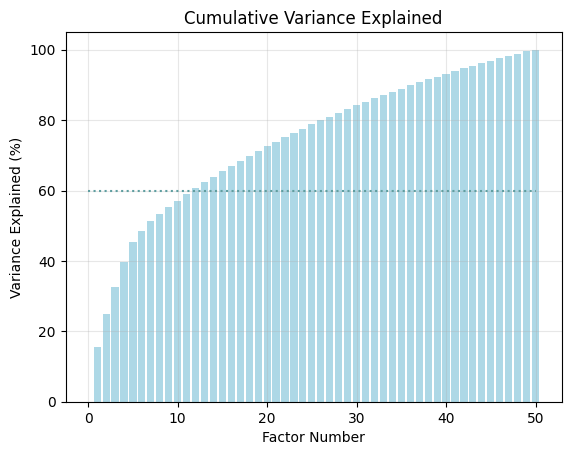

```python
plt.bar(variance_explained.Factor_Number, variance_explained.Cumulative_Variance,color = 'lightblue')
plt.xlabel('Factor Number')
plt.ylabel('Variance Explained (%)')
plt.title('Cumulative Variance Explained')
plt.hlines(60,linestyles='dotted', colors='cadetblue',xmin =0, xmax = 50)
plt.grid(True, alpha=0.3)
```

### Extracted Communalities

- Communality reflects the amount of variance in a variable that can be explained by the factors.
- Larger the communality, the more of the variable is captured by the factor solution.
- On the other hand, a small communality implies most of the variance in the variable was not captured. Ideally, communality of each variable must be greater than 0.7, but a communality greater than 0.5 may be seen as acceptable. For larget datasets, this threshold may be relaxed to 0.3.

```python
fa5 = FactorAnalyzer(n_factors=5, rotation=None)
fa5.fit(survey_scaled)
fa5.get_communalities()
print('Number of factors with a communality greater than 0.3: ', np.sum(fa5.get_communalities()>0.3))
#fa5.get_communalities() + fa5.get_uniquenesses() # This represents total variance scaled to 1
```

```
Number of factors with a communality greater than 0.3:  38
```

## Mapping Variables to Factors

Based on the data-driven tests, there is only partial support for the apriori expectation of 5 factors. Since these personality surveys have been rigorously tested, we will go with the partially supported theoretical expectation of 5 factors.

Each variable is represented as a linear combination of factors. An ideal factor solution is where each variable is expected to load on (i.e., related to) only one factor. Such a result is easy to interpret. In practice, each variable may load on many factors. This may still be acceptable so long as the loading on one factor is large and on all other factors is small.

When the pattern of loadings does not show a clear preference of a variable for a factor, rotating the axes may help generate a clear mapping. There are two broad types of axes rotation

- Orthogonal: Axes are rotated while constraining them to be at right angles. E.g., varimax, quartimax, equimax
- Oblique: Axes are allowed to have any angle between them. E.g., oblimin, promax

Here, we will examine the results of an unrotated solution, then Varimax and Oblimin. The heatmap helps to visualize the pattern of loadings.

```python
fa_unrotated = FactorAnalyzer(n_factors=5, rotation=None)
fa_unrotated.fit(survey_scaled)
results = pd.DataFrame(fa_unrotated.loadings_,
             index=survey.columns,
             columns=['Factor_1','Factor_2','Factor_3','Factor_4','Factor_5'])
results
```

|  | Factor_1 | Factor_2 | Factor_3 | Factor_4 | Factor_5 |
| --- | --- | --- | --- | --- | --- |
| E1 | 0.504968 | 0.256821 | -0.293893 | -0.106213 | 0.228763 |
| E2 | 0.492937 | 0.336577 | -0.267447 | -0.155766 | 0.198960 |
| E3 | 0.681087 | 0.147108 | -0.109491 | -0.213386 | 0.093087 |
| E4 | 0.568907 | 0.192969 | -0.293067 | -0.185750 | 0.227996 |
| E5 | 0.637662 | 0.277912 | -0.171391 | -0.114089 | 0.202487 |
| E6 | 0.510510 | 0.244028 | -0.182766 | 0.067245 | 0.130596 |
| E7 | 0.575501 | 0.258734 | -0.237154 | -0.148986 | 0.216150 |
| E8 | 0.362954 | 0.197509 | -0.310165 | -0.072621 | 0.200199 |
| E9 | 0.458680 | 0.246733 | -0.343938 | 0.019752 | 0.215977 |
| E10 | 0.556508 | 0.151059 | -0.309574 | -0.135340 | 0.180176 |
| N1 | -0.419440 | 0.485977 | 0.238552 | 0.001846 | 0.225563 |
| N2 | -0.323717 | 0.282247 | 0.173687 | 0.041391 | 0.225242 |
| N3 | -0.333667 | 0.424683 | 0.318605 | 0.042474 | 0.145860 |
| N4 | -0.265755 | 0.227642 | 0.091068 | 0.080277 | 0.051415 |
| N5 | -0.399828 | 0.383278 | 0.037633 | -0.078682 | 0.180626 |
| N6 | -0.453256 | 0.501959 | 0.157434 | -0.006907 | 0.261481 |
| N7 | -0.456326 | 0.524993 | -0.028615 | 0.087314 | 0.221558 |
| N8 | -0.483068 | 0.523644 | -0.008535 | 0.075829 | 0.243282 |
| N9 | -0.514354 | 0.399825 | 0.016488 | 0.055173 | 0.349232 |
| N10 | -0.527279 | 0.357375 | 0.095334 | 0.154113 | 0.073714 |
| A1 | 0.255840 | 0.172391 | 0.280125 | -0.049125 | -0.213148 |
| A2 | 0.484022 | 0.337769 | 0.186929 | -0.118034 | -0.152622 |
| A3 | 0.249432 | -0.112878 | 0.349880 | -0.112979 | -0.220975 |
| A4 | 0.302009 | 0.407927 | 0.494921 | -0.170173 | -0.294815 |
| A5 | 0.339895 | 0.322409 | 0.333422 | -0.159793 | -0.239547 |
| A6 | 0.147833 | 0.349871 | 0.397711 | -0.169060 | -0.215397 |
| A7 | 0.506344 | 0.318292 | 0.251406 | -0.178028 | -0.225895 |
| A8 | 0.350582 | 0.273359 | 0.345153 | -0.113795 | -0.164237 |
| A9 | 0.292536 | 0.430359 | 0.410165 | -0.104882 | -0.226166 |
| A10 | 0.485868 | 0.186250 | 0.143377 | -0.048027 | -0.031949 |
| C1 | 0.279300 | -0.239876 | 0.387228 | 0.147601 | 0.352997 |
| C2 | 0.121824 | -0.336597 | 0.283909 | -0.029285 | 0.342677 |
| C3 | 0.193255 | -0.024869 | 0.287665 | 0.278865 | 0.147782 |
| C4 | 0.385290 | -0.420782 | 0.287202 | 0.006334 | 0.199123 |
| C5 | 0.266334 | -0.251884 | 0.355529 | 0.001961 | 0.361806 |
| C6 | 0.227562 | -0.346223 | 0.313598 | -0.009465 | 0.317972 |
| C7 | 0.100669 | -0.132782 | 0.392515 | 0.106852 | 0.385893 |
| C8 | 0.337294 | -0.244035 | 0.309677 | 0.040328 | 0.122432 |
| C9 | 0.235249 | -0.148024 | 0.450440 | 0.020184 | 0.359980 |
| C10 | 0.243306 | -0.081980 | 0.310767 | 0.266482 | 0.244796 |
| O1 | 0.201879 | 0.075612 | -0.048412 | 0.525647 | -0.032760 |
| O2 | 0.275038 | -0.002877 | -0.043167 | 0.479892 | -0.176780 |
| O3 | 0.114389 | 0.247285 | -0.064237 | 0.457545 | -0.146855 |
| O4 | 0.214281 | 0.107271 | 0.014010 | 0.415373 | -0.220539 |
| O5 | 0.366997 | 0.051685 | -0.070252 | 0.512394 | 0.063766 |
| O6 | 0.220726 | 0.123527 | -0.041813 | 0.406684 | -0.150826 |
| O7 | 0.310690 | -0.032418 | 0.024112 | 0.403395 | 0.031848 |
| O8 | 0.072379 | 0.137525 | -0.106197 | 0.526104 | 0.007629 |
| O9 | 0.021779 | 0.193630 | 0.228228 | 0.340471 | -0.095688 |
| O10 | 0.348395 | 0.164839 | -0.101388 | 0.567315 | -0.056282 |

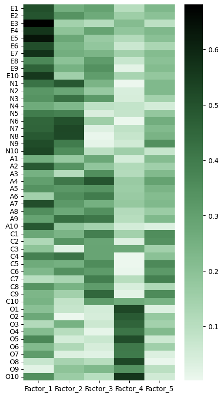

```python
plt.figure(figsize = (5,10))
color_palette = sns.cubehelix_palette(start=2, rot=0, dark=0, light=.95, reverse=False, as_cmap=True)
sns.heatmap(results.abs(),cmap = color_palette)
plt.show()
```

```python
fa_varimax = FactorAnalyzer(n_factors=5, rotation='varimax')
fa_varimax.fit(survey_scaled)
results = pd.DataFrame(fa_varimax.loadings_,
             index=survey.columns,
             columns=['Factor_1','Factor_2','Factor_3','Factor_4','Factor_5'])
results
```

|  | Factor_1 | Factor_2 | Factor_3 | Factor_4 | Factor_5 |
| --- | --- | --- | --- | --- | --- |
| E1 | 0.679357 | -0.054603 | 0.055506 | 0.000703 | 0.057860 |
| E2 | 0.687460 | -0.005870 | 0.129021 | -0.040779 | 0.026506 |
| E3 | 0.630522 | -0.259698 | 0.275601 | 0.103678 | -0.000948 |
| E4 | 0.712014 | -0.141457 | 0.072114 | 0.031342 | -0.010463 |
| E5 | 0.706857 | -0.099185 | 0.205482 | 0.088266 | 0.087988 |
| E6 | 0.549123 | -0.069890 | 0.121440 | 0.036490 | 0.229457 |
| E7 | 0.702863 | -0.089846 | 0.134873 | 0.041149 | 0.036489 |
| E8 | 0.553461 | -0.032896 | -0.031906 | -0.041712 | 0.046274 |
| E9 | 0.637333 | -0.038846 | -0.023107 | -0.030580 | 0.165594 |
| E10 | 0.664997 | -0.182680 | 0.047547 | 0.009562 | 0.034511 |
| N1 | -0.100920 | 0.703261 | 0.098822 | -0.007111 | -0.072899 |
| N2 | -0.095179 | 0.502551 | -0.005444 | 0.059238 | -0.043764 |
| N3 | -0.148153 | 0.599953 | 0.179653 | 0.043816 | -0.013781 |
| N4 | -0.121804 | 0.346936 | 0.011731 | -0.059162 | 0.031448 |
| N5 | -0.036650 | 0.555521 | -0.022143 | -0.126434 | -0.143437 |
| N6 | -0.062047 | 0.731695 | 0.029141 | -0.050756 | -0.089198 |
| N7 | -0.005316 | 0.707023 | -0.080361 | -0.186272 | 0.017776 |
| N8 | -0.020862 | 0.732200 | -0.086203 | -0.168994 | -0.004934 |
| N9 | -0.050945 | 0.710956 | -0.182475 | -0.053966 | -0.073724 |
| N10 | -0.249012 | 0.593740 | -0.057313 | -0.154016 | 0.049725 |
| A1 | 0.021336 | -0.060060 | 0.458322 | 0.041341 | 0.075216 |
| A2 | 0.315024 | -0.063733 | 0.554697 | 0.018307 | 0.095960 |
| A3 | -0.114274 | -0.252589 | 0.388641 | 0.171858 | -0.039136 |
| A4 | 0.032101 | 0.071847 | 0.781499 | 0.033160 | 0.020059 |
| A5 | 0.120003 | -0.013007 | 0.631113 | 0.012187 | 0.023258 |
| A6 | -0.011273 | 0.129130 | 0.599250 | 0.000835 | -0.038901 |
| A7 | 0.273544 | -0.115159 | 0.642317 | 0.017029 | 0.051699 |
| A8 | 0.125032 | -0.013053 | 0.574376 | 0.093687 | 0.046887 |
| A9 | 0.089366 | 0.113290 | 0.688640 | 0.022423 | 0.074990 |
| A10 | 0.315020 | -0.118685 | 0.387665 | 0.132261 | 0.116361 |
| C1 | 0.027836 | -0.072928 | 0.038521 | 0.645113 | 0.090223 |
| C2 | -0.030709 | -0.099811 | -0.081011 | 0.541740 | -0.126802 |
| C3 | -0.013308 | 0.028379 | 0.102759 | 0.370503 | 0.267410 |
| C4 | 0.037756 | -0.355587 | 0.042233 | 0.563754 | -0.014525 |
| C5 | 0.063433 | -0.091975 | 0.040858 | 0.612333 | -0.050830 |
| C6 | 0.005613 | -0.165407 | -0.019700 | 0.580637 | -0.079223 |
| C7 | -0.026754 | 0.107018 | 0.015772 | 0.573952 | 0.018063 |
| C8 | 0.024426 | -0.232541 | 0.143904 | 0.456264 | 0.047735 |
| C9 | 0.034486 | 0.015807 | 0.130029 | 0.625311 | -0.027984 |
| C10 | 0.030053 | 0.007328 | 0.069238 | 0.478897 | 0.241536 |
| O1 | 0.059147 | -0.021647 | -0.032351 | 0.050559 | 0.564468 |
| O2 | 0.022578 | -0.181417 | 0.040975 | 0.006272 | 0.551294 |
| O3 | 0.041445 | 0.084472 | 0.070728 | -0.127026 | 0.528473 |
| O4 | -0.006236 | -0.087643 | 0.138130 | -0.052058 | 0.499281 |
| O5 | 0.210346 | -0.089061 | -0.033013 | 0.151802 | 0.576712 |
| O6 | 0.061292 | -0.060829 | 0.084238 | -0.047592 | 0.486878 |
| O7 | 0.107130 | -0.125623 | 0.006235 | 0.189209 | 0.445877 |
| O8 | 0.042921 | 0.096623 | -0.108589 | -0.018622 | 0.537546 |
| O9 | -0.128672 | 0.160778 | 0.194588 | 0.061437 | 0.362059 |
| O10 | 0.193909 | -0.052567 | 0.033190 | 0.018414 | 0.664861 |

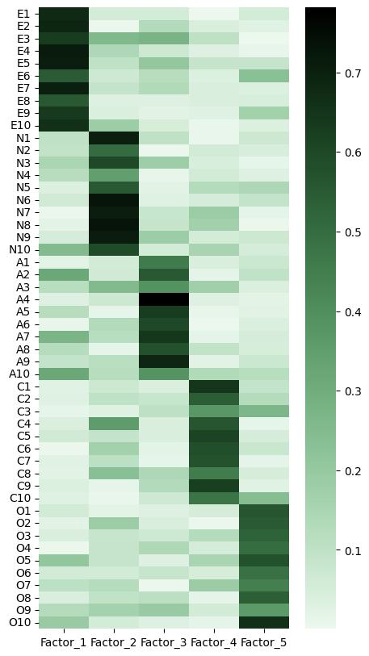

```python
plt.figure(figsize = (5,10))
color_palette = sns.cubehelix_palette(start=2, rot=0, dark=0, light=.95, reverse=False, as_cmap=True)
sns.heatmap(results.abs(),cmap = color_palette)
plt.show()
```

```python
fa_oblimin = FactorAnalyzer(n_factors=5, rotation='oblimin')
fa_oblimin.fit(survey_scaled)
results = pd.DataFrame(fa_oblimin.loadings_,
             index=survey.columns,
             columns=['Factor_1','Factor_2','Factor_3','Factor_4','Factor_5'])
results
```

|  | Factor_1 | Factor_2 | Factor_3 | Factor_4 | Factor_5 |
| --- | --- | --- | --- | --- | --- |
| E1 | 0.696761 | 0.041441 | -0.024780 | -0.008401 | 0.016382 |
| E2 | 0.705260 | 0.084305 | 0.054267 | -0.049155 | -0.017939 |
| E3 | 0.612144 | -0.177321 | 0.194204 | 0.064132 | -0.056431 |
| E4 | 0.730363 | -0.040902 | -0.015269 | 0.014681 | -0.058252 |
| E5 | 0.702330 | 0.001960 | 0.117796 | 0.067275 | 0.037941 |
| E6 | 0.530986 | 0.007348 | 0.052841 | 0.018103 | 0.194924 |
| E7 | 0.712647 | 0.009081 | 0.050200 | 0.025362 | -0.011063 |
| E8 | 0.576955 | 0.044775 | -0.095849 | -0.044506 | 0.015984 |
| E9 | 0.649370 | 0.052056 | -0.099099 | -0.037185 | 0.132042 |
| E10 | 0.674823 | -0.091737 | -0.035074 | -0.011902 | -0.010308 |
| N1 | -0.050310 | 0.706406 | 0.133570 | 0.063544 | -0.049915 |
| N2 | -0.053187 | 0.512917 | 0.015525 | 0.115488 | -0.022038 |
| N3 | -0.124165 | 0.594425 | 0.214700 | 0.098470 | 0.006210 |
| N4 | -0.104582 | 0.333276 | 0.039509 | -0.025509 | 0.049185 |
| N5 | 0.026649 | 0.555254 | 0.007542 | -0.065589 | -0.125515 |
| N6 | 0.002304 | 0.740035 | 0.061743 | 0.026335 | -0.064942 |
| N7 | 0.058927 | 0.712792 | -0.049400 | -0.111640 | 0.043694 |
| N8 | 0.047967 | 0.738839 | -0.053831 | -0.090342 | 0.022694 |
| N9 | 0.032938 | 0.730865 | -0.156865 | 0.032654 | -0.041081 |
| N10 | -0.212815 | 0.562156 | -0.003103 | -0.093284 | 0.085362 |
| A1 | -0.040321 | -0.077808 | 0.461480 | 0.007654 | 0.053108 |
| A2 | 0.255365 | -0.045789 | 0.527176 | -0.021851 | 0.053096 |
| A3 | -0.177670 | -0.278203 | 0.392830 | 0.127751 | -0.057720 |
| A4 | -0.045973 | 0.042402 | 0.796153 | -0.003863 | -0.013752 |
| A5 | 0.055123 | -0.026998 | 0.630977 | -0.025633 | -0.011644 |
| A6 | -0.060376 | 0.100812 | 0.619134 | -0.018955 | -0.061462 |
| A7 | 0.203545 | -0.109887 | 0.621033 | -0.032610 | 0.004834 |
| A8 | 0.063496 | -0.013726 | 0.566146 | 0.060605 | 0.015221 |
| A9 | 0.020916 | 0.097383 | 0.695537 | -0.006433 | 0.044288 |
| A10 | 0.266033 | -0.080508 | 0.346176 | 0.098259 | 0.080335 |
| C1 | 0.007485 | 0.002765 | -0.012999 | 0.649290 | 0.090758 |
| C2 | -0.017373 | -0.039959 | -0.119212 | 0.552878 | -0.122829 |
| C3 | -0.055169 | 0.066018 | 0.077749 | 0.370016 | 0.271589 |
| C4 | 0.007064 | -0.298045 | -0.010904 | 0.538331 | -0.026261 |
| C5 | 0.060050 | -0.015828 | -0.011159 | 0.617284 | -0.055574 |
| C6 | 0.003158 | -0.100971 | -0.065812 | 0.581082 | -0.081108 |
| C7 | -0.024004 | 0.173515 | -0.019038 | 0.598551 | 0.026857 |
| C8 | -0.015012 | -0.190602 | 0.105044 | 0.433669 | 0.036457 |
| C9 | 0.026197 | 0.088295 | 0.085285 | 0.636262 | -0.031096 |
| C10 | -0.004796 | 0.065138 | 0.030354 | 0.481637 | 0.244459 |
| O1 | -0.003899 | -0.005258 | -0.051379 | 0.036732 | 0.571507 |
| O2 | -0.061567 | -0.184976 | 0.026997 | -0.029642 | 0.551350 |
| O3 | -0.020230 | 0.075573 | 0.072310 | -0.139129 | 0.533476 |
| O4 | -0.088203 | -0.104232 | 0.137262 | -0.083781 | 0.498398 |
| O5 | 0.147973 | -0.040617 | -0.078943 | 0.133416 | 0.574025 |
| O6 | -0.007816 | -0.063183 | 0.074731 | -0.072775 | 0.485315 |
| O7 | 0.047949 | -0.091531 | -0.028691 | 0.168842 | 0.444170 |
| O8 | 0.000155 | 0.110452 | -0.119085 | -0.016562 | 0.551821 |
| O9 | -0.186286 | 0.144837 | 0.209780 | 0.059135 | 0.372230 |
| O10 | 0.116256 | -0.024334 | 0.000204 | -0.005655 | 0.661800 |

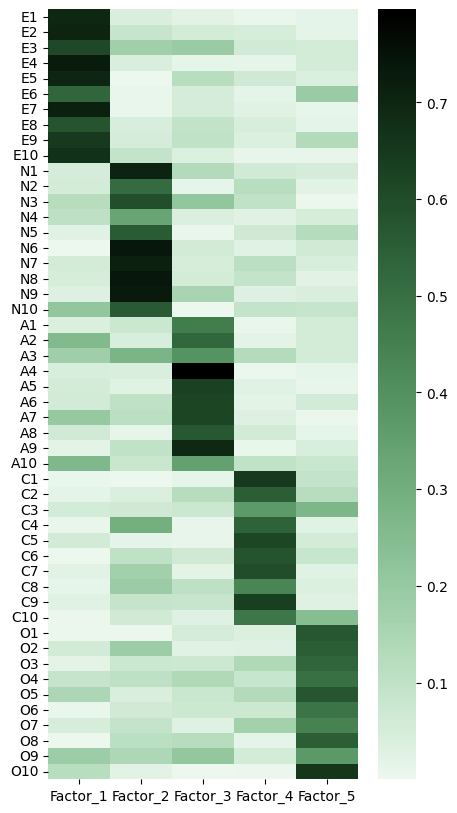

```python
plt.figure(figsize = (5,10))
color_palette = sns.cubehelix_palette(start=2, rot=0, dark=0, light=.95, reverse=False, as_cmap=True)
sns.heatmap(results.abs(),cmap = color_palette)
plt.show()
```

## Intepretation and Representation

The pattern of factor loadings in the factor analysis with oblimin rotation, supports the existence of five latent variables measuring. Based on our knowledge of the content of the items, we can replace the factor numbers with latent variables or constructs. Specifically,

- Factor 1 (E1-E10): Extraversion
- Factor 2 (N1-N10): Neuroticism
- Factor 3 (A1-A10): Agreeableness
- Factor 4 (C1-C10): Conscientiousness
- Factor 5 (O1-O10): Openness to Experience

```python
fa_oblimin = FactorAnalyzer(n_factors=5, rotation='oblimin')
fa_oblimin.fit(survey_scaled)
results = pd.DataFrame(fa_oblimin.loadings_,
             index=survey.columns,
             columns=['Extraversion','Neuroticism','Agreeableness','Conscientiousness','Openness to Experience'])
results
```

|  | Extraversion | Neuroticism | Agreeableness | Conscientiousness | Openness to Experience |
| --- | --- | --- | --- | --- | --- |
| E1 | 0.696761 | 0.041441 | -0.024780 | -0.008401 | 0.016382 |
| E2 | 0.705260 | 0.084305 | 0.054267 | -0.049155 | -0.017939 |
| E3 | 0.612144 | -0.177321 | 0.194204 | 0.064132 | -0.056431 |
| E4 | 0.730363 | -0.040902 | -0.015269 | 0.014681 | -0.058252 |
| E5 | 0.702330 | 0.001960 | 0.117796 | 0.067275 | 0.037941 |
| E6 | 0.530986 | 0.007348 | 0.052841 | 0.018103 | 0.194924 |
| E7 | 0.712647 | 0.009081 | 0.050200 | 0.025362 | -0.011063 |
| E8 | 0.576955 | 0.044775 | -0.095849 | -0.044506 | 0.015984 |
| E9 | 0.649370 | 0.052056 | -0.099099 | -0.037185 | 0.132042 |
| E10 | 0.674823 | -0.091737 | -0.035074 | -0.011902 | -0.010308 |
| N1 | -0.050310 | 0.706406 | 0.133570 | 0.063544 | -0.049915 |
| N2 | -0.053187 | 0.512917 | 0.015525 | 0.115488 | -0.022038 |
| N3 | -0.124165 | 0.594425 | 0.214700 | 0.098470 | 0.006210 |
| N4 | -0.104582 | 0.333276 | 0.039509 | -0.025509 | 0.049185 |
| N5 | 0.026649 | 0.555254 | 0.007542 | -0.065589 | -0.125515 |
| N6 | 0.002304 | 0.740035 | 0.061743 | 0.026335 | -0.064942 |
| N7 | 0.058927 | 0.712792 | -0.049400 | -0.111640 | 0.043694 |
| N8 | 0.047967 | 0.738839 | -0.053831 | -0.090342 | 0.022694 |
| N9 | 0.032938 | 0.730865 | -0.156865 | 0.032654 | -0.041081 |
| N10 | -0.212815 | 0.562156 | -0.003103 | -0.093284 | 0.085362 |
| A1 | -0.040321 | -0.077808 | 0.461480 | 0.007654 | 0.053108 |
| A2 | 0.255365 | -0.045789 | 0.527176 | -0.021851 | 0.053096 |
| A3 | -0.177670 | -0.278203 | 0.392830 | 0.127751 | -0.057720 |
| A4 | -0.045973 | 0.042402 | 0.796153 | -0.003863 | -0.013752 |
| A5 | 0.055123 | -0.026998 | 0.630977 | -0.025633 | -0.011644 |
| A6 | -0.060376 | 0.100812 | 0.619134 | -0.018955 | -0.061462 |
| A7 | 0.203545 | -0.109887 | 0.621033 | -0.032610 | 0.004834 |
| A8 | 0.063496 | -0.013726 | 0.566146 | 0.060605 | 0.015221 |
| A9 | 0.020916 | 0.097383 | 0.695537 | -0.006433 | 0.044288 |
| A10 | 0.266033 | -0.080508 | 0.346176 | 0.098259 | 0.080335 |
| C1 | 0.007485 | 0.002765 | -0.012999 | 0.649290 | 0.090758 |
| C2 | -0.017373 | -0.039959 | -0.119212 | 0.552878 | -0.122829 |
| C3 | -0.055169 | 0.066018 | 0.077749 | 0.370016 | 0.271589 |
| C4 | 0.007064 | -0.298045 | -0.010904 | 0.538331 | -0.026261 |
| C5 | 0.060050 | -0.015828 | -0.011159 | 0.617284 | -0.055574 |
| C6 | 0.003158 | -0.100971 | -0.065812 | 0.581082 | -0.081108 |
| C7 | -0.024004 | 0.173515 | -0.019038 | 0.598551 | 0.026857 |
| C8 | -0.015012 | -0.190602 | 0.105044 | 0.433669 | 0.036457 |
| C9 | 0.026197 | 0.088295 | 0.085285 | 0.636262 | -0.031096 |
| C10 | -0.004796 | 0.065138 | 0.030354 | 0.481637 | 0.244459 |
| O1 | -0.003899 | -0.005258 | -0.051379 | 0.036732 | 0.571507 |
| O2 | -0.061567 | -0.184976 | 0.026997 | -0.029642 | 0.551350 |
| O3 | -0.020230 | 0.075573 | 0.072310 | -0.139129 | 0.533476 |
| O4 | -0.088203 | -0.104232 | 0.137262 | -0.083781 | 0.498398 |
| O5 | 0.147973 | -0.040617 | -0.078943 | 0.133416 | 0.574025 |
| O6 | -0.007816 | -0.063183 | 0.074731 | -0.072775 | 0.485315 |
| O7 | 0.047949 | -0.091531 | -0.028691 | 0.168842 | 0.444170 |
| O8 | 0.000155 | 0.110452 | -0.119085 | -0.016562 | 0.551821 |
| O9 | -0.186286 | 0.144837 | 0.209780 | 0.059135 | 0.372230 |
| O10 | 0.116256 | -0.024334 | 0.000204 | -0.005655 | 0.661800 |

### Representing Factors

Factors may be represented as

- arithmetic mean of the items loading on it
- weighted mean of items loading on it where weights are derived from factor loadings

#### Factor Score as Arithmetic Mean

```python
survey_factors = pd.DataFrame()
survey_factors['Extraversion'] = survey.loc[:,'E1':'E10'].mean(axis = 1)
survey_factors['Neuroticism'] = survey.loc[:,'N1':'N10'].mean(axis = 1)
survey_factors['Agreeableness'] = survey.loc[:,'A1':'A10'].mean(axis = 1)
survey_factors['Conscientiousness'] = survey.loc[:,'C1':'C10'].mean(axis = 1)
survey_factors['Openness to Experience'] = survey.loc[:,'O1':'O10'].mean(axis = 1)
survey_factors.head()
```

|  | Extraversion | Neuroticism | Agreeableness | Conscientiousness | Openness to Experience |
| --- | --- | --- | --- | --- | --- |
| 0 | 2.6 | 2.8 | 3.9 | 2.4 | 4.1 |
| 1 | 3.5 | 4.0 | 3.5 | 3.1 | 3.9 |
| 2 | 1.3 | 3.3 | 2.9 | 3.0 | 3.8 |
| 3 | 1.4 | 1.6 | 4.0 | 4.0 | 3.7 |
| 4 | 0.7 | 3.3 | 2.9 | 3.4 | 2.7 |

#### Factor Scores derived from Loadings

```python
survey_factors_weighted = survey @ results
survey_factors_weighted.head()
```

|  | Extraversion | Neuroticism | Agreeableness | Conscientiousness | Openness to Experience |
| --- | --- | --- | --- | --- | --- |
| 0 | 17.201677 | 15.354662 | 26.036234 | 13.524317 | 24.983596 |
| 1 | 23.955728 | 24.338911 | 23.627866 | 18.086127 | 23.044887 |
| 2 | 8.421701 | 19.756195 | 18.512088 | 17.840714 | 21.944100 |
| 3 | 10.284981 | 7.033552 | 25.600411 | 23.591179 | 21.089427 |
| 4 | 4.905069 | 17.096695 | 18.398081 | 20.590561 | 14.682080 |

## Conclusion

In this note, we explored survey data, evaluated it for suitability for factor analysis, standardized features, examined heuristics for determining optimal number of factors, mapped variables to factors by rotating axes, and represented the resulting factors as a combination of items they represent.

This file was generated using Python 3.13.5 on Windows 10 with the following libraries: factor_analyzer 0.5.1, matplotlib 3.10.3, numpy 2.3.1, pandas 2.3.0, scikit-learn 1.7.1, seaborn 0.13.2